## 1 Equations

Can use `$...$` (`$$...$$` for blocks) or `\(...\)` (`\[...\]` for blocks) to enclose equations. Difference:

- `$...$` provides rendered equation previews in RStudio.
- `\(...\)` does not have previews.

Rstudio equation previews do NOT work well with indented equations. $\rightarrow$ reduce indentation

如果公式缩进，Rstudio 公式预览功能可能不识别。在不影响理解的前提下，减少不必要的缩进以便预览公式。

**Multi-case** functions using `\begin{cases}`

```markdown
\begin{align*}
I_t =
\begin{cases}
1 & \text{if } r_t>0 \\
0 & \text{if } r_t\leq0
\end{cases}
\end{align*}
```

will render as

$$\begin{align*}
I_t =
\begin{cases}
1 & \text{if } r_t>0 \\
0 & \text{if } r_t\leq0
\end{cases}
\end{align*}$$

For equation numbering support in `bookdown` you need to [assign labels](https://bookdown.org/yihui/bookdown/markdown-extensions-by-bookdown.html#equations).

You may refer to an equation using Eq. `\@ref(eq:eq01)`.

```latex
\begin{align} (\#eq:eq01)
\frac{p(x)}{1-p(x)} = \exp (\beta_0+\beta_1 x) \,.
\end{align}
```

If you want to provide a specific number to the equation, you can use `\tag{XX.XX}`.

- With LaTeX

  LaTex allows custom labels.

  $$\begin{align} \label{eq:my-label-latex} \tag{my label latex}
  \frac{p(x)}{1-p(x)} = \exp (\beta_0+\beta_1 x) \,.
  \end{align}$$

  My specific label here, see eq $\eqref{eq:my-label-latex}$ (`\eqref{eq:my-label-latex}`).
- With `bookdown`

  `bookdown` does NOT support custom tag though.

  $$\begin{align}
  \frac{p(x)}{1-p(x)} = \exp (\beta_0+\beta_1 x) \,.
  \tag{1}
  \end{align}$$

  My specific label here, see eq (1)

**Color eqns** using `\color{#00CC66}{...}`.

But sometime everything follows gets colored. You may want to use `{\color{#00CC66} ... }` instead.

```latex
$$
\color{#008B45}{Y_t} = I_tI_{t-1} + (1-I_t)(1-I_{t-1})
$$
```

**A workaround**: We can write a custom R function to insert the correct syntax depending on the output format using the `is_latex_output()` and `is_html_output()` functions in knitr as follows:

```r
colorize <- function(x, color) {
  if (knitr::is_latex_output()) {
    sprintf("\\textcolor{%s}{%s}", color, x)
  } else if (knitr::is_html_output()) {
    sprintf("<span style='color: %s;'>%s</span>", color,
      x)
  } else x
}
```

### Mathjax

https://bookdown.org/yihui/rmarkdown/html-document.html#mathjax-equations

Default configuration used by the rmarkdown package is given by `rmarkdown:::mathjax_config()`. As of rmarkdown v2.1, the function returns “MathJax.js?config=TeX-AMS-MML_HTMLorMML”. This configures `Mathjax` to `HTML-CSS`.

Change `Mathjax` configuration to `CommonHTML` using the following codes.

```markdown
---
title: "Trouble with MathJax"
output:
  html_document:
    mathjax: "https://cdnjs.cloudflare.com/ajax/libs/mathjax/2.7.5/MathJax.js?config=TeX-AMS_CHTML.js"
    self_contained: false
---
```

By default, [MathJax](https://www.mathjax.org/) scripts are included in HTML documents for rendering LaTeX and MathML equations. You can use the `mathjax` option to control how MathJax is included:

- Specify `"default"` to use an HTTPS URL from a CDN host (currently provided by RStudio).
- Specify `"local"` to use a local version of MathJax (which is copied into the output directory). Note that when using `"local"` you also need to set the `self_contained` option to `false`.
- Specify an alternate URL to load MathJax from another location. To use a self-hosted copy of MathJax.
- Specify `null` to exclude MathJax entirely.

Q: Why my eqns are not rendered?

A: MathJax is unlikely to work offline. Check internet connection.

You load [MathJax](https://docs.mathjax.org/en/stable/configuration.html) into a web page by including its main JavaScript file into the page. That is done via a `<script>`tag that links to the `MathJax.js` file. To do that, place the following line in the `<head>` section of your document.

For example, if you are using the MathJax distributed network service, the tag might be

```html
<script type="text/javascript"
   src="http://cdn.mathjax.org/mathjax/latest/MathJax.js">
</script>
```

MathJax is available as a web service from `cdn.mathjax.org`, so you can obtain MathJax from there without needing to install it on your own server. The CDN is part of a distributed “cloud” network, so it is handled by servers around the world. That means that you should get access to a server geographically near you, for a fast, reliable connection.

The CDN hosts the most current version of MathJax, as well as older versions, so you can either link to a version that stays up-to-date as MathJax is improved, or you can stay with one of the release versions so that your pages always use the same version of MathJax.

For equation numbering support in `bookdown::pdf_document2` you need to [assign labels](https://bookdown.org/yihui/bookdown/markdown-extensions-by-bookdown.html#equations). Defualt behavior is not adding numbering.

- Use `\begin{equation}...\end{equations}` or `\begin{align}...\end{align}` environments.
  - Use `(\#eq:eq1)` or `\label{eq:eq1}` to add labels.
  - Automatically add numbering.
  - Drawback is that rmd does not have preview of equations.
- Do NOT enclose the environments in double dollar signs `$$`. Otherwise, no label is added, but cross-references still show up.
  - `$$` do not add numbering automatically.
  - But in `bookdown::html_document2`, it is ok to use

    ```latex
    $$
    \begin{equation} (\#eq:simple-lm)
    \hat{\beta}_{\text{OLS}} = \left(\sum_{i=1}^n x_i x_i' \right)^{-1} \left(\sum_{i=1}^n x_i y_i \right) .
    \end{equation}
    $$
    ```

    Then reference with `\@ref(eq:simple-lm)`.
- Use `\@ref(eq:eq1)` (note this use parentheses) or the Latex command `\eqref{eq:eq1}` (this uses curly braces) to cite the equation.

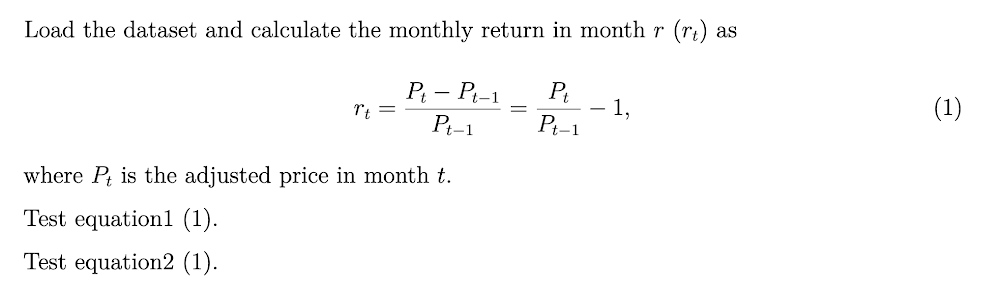

```latex
Load the dataset and calculate the monthly return in month $r$ ($r_t$) as

\begin{equation}
r_t = \frac{P_t-P_{t-1}}{P_{t-1}} = \frac{P_t}{P_{t-1}}-1 ,
(\#eq:eq1)
\end{equation}

where $P_t$ is the adjusted price in month $t$.

Test equation1 \@ref(eq:eq1).

Test equation2 \eqref{eq:eq1}.
```